# Regression Analysis

Kar

2022-06-07

## 1 INTRODUCTION

This project will analyse the business datasets used in the book **“ESSENTIALS OF STATISTICS FOR BUSINESS AND ECONOMICS”** by David R.Anderson (University of Cincinnati), Dennis J. Sweeney (University of Cincinnati), and Thomas A. Williams (Rochester Institute of Technology).

## 2 R PACKAGES

```r
library(tidyverse)
library(cowplot)
library(kableExtra)
```

## 3 ANALYSIS

### 3.1 Transportation Schedule

To develop a better work schedules, the managers of Butler Trucking Company wants to estimate the total daily travel time for their drivers.

There are 2 explanatory variables “miles traveled” and “number of deliveries”, and 1 responding variable “travel time per hour”. This analysis will find out the statistical relationship between the responding variable with these explanatory variable.

Dataset:

```r
driving.assignment <- c(1:10)
miles.traveled <- c(100, 50, 100, 100, 50, 80, 75, 65, 90, 90)
number.of.deliveries <- c(4, 3, 4, 2, 2, 2, 3, 4, 3, 2)
travel.time.hrs <- c(9.3, 4.8, 8.9, 6.5, 4.2, 6.2, 7.4, 6, 7.6, 6.1)

transport.df <- data.frame(driving.assignment, miles.traveled, number.of.deliveries, travel.time.hrs)

transport.df %>% kbl() %>% kable_styling(bootstrap_options = c("striped", "bordered"), full_width = F)
```

| driving.assignment | miles.traveled | number.of.deliveries | travel.time.hrs |
| --- | --- | --- | --- |
| 1 | 100 | 4 | 9.3 |
| 2 | 50 | 3 | 4.8 |
| 3 | 100 | 4 | 8.9 |
| 4 | 100 | 2 | 6.5 |
| 5 | 50 | 2 | 4.2 |
| 6 | 80 | 2 | 6.2 |
| 7 | 75 | 3 | 7.4 |
| 8 | 65 | 4 | 6.0 |
| 9 | 90 | 3 | 7.6 |
| 10 | 90 | 2 | 6.1 |

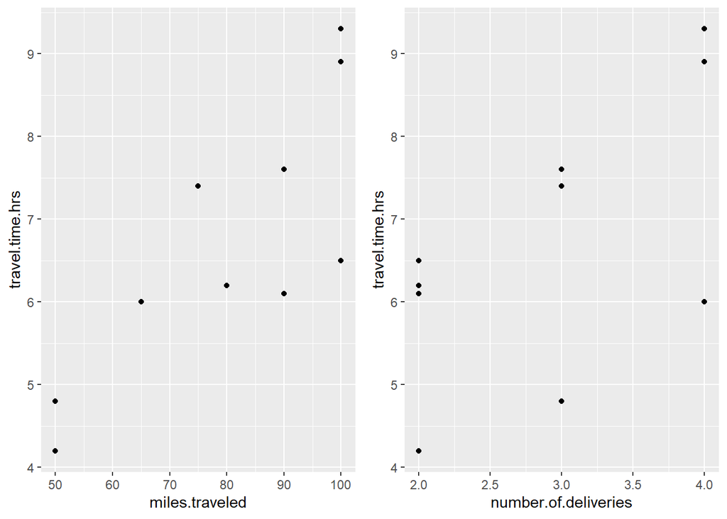

```r
g1.transport <- ggplot(transport.df, aes(x = miles.traveled, y = travel.time.hrs)) + geom_point()
g2.transport <- ggplot(transport.df, aes(x = number.of.deliveries, y = travel.time.hrs)) + geom_point()

plot_grid(g1.transport, g2.transport)
```

**Simple linear Regression**:

The dataset will be analysed with multiple linear regression method, but following is a simple linear regression, it is an optional step, I create it to compare with multiple linear regression on how metrics change.

```r
transport.lm <- lm(travel.time.hrs ~ miles.traveled,
                   data = transport.df)

summary(transport.lm)
```

```
##
## Call:
## lm(formula = travel.time.hrs ~ miles.traveled, data = transport.df)
##
## Residuals:
##     Min      1Q  Median      3Q     Max
## -1.5565 -0.4913  0.1783  0.7120  1.2435
##
## Coefficients:
##                Estimate Std. Error t value Pr(>|t|)
## (Intercept)     1.27391    1.40074   0.909  0.38969
## miles.traveled  0.06783    0.01706   3.977  0.00408 **
## ---
## Signif. codes:  0 '***' 0.001 '**' 0.01 '*' 0.05 '.' 0.1 ' ' 1
##
## Residual standard error: 1.002 on 8 degrees of freedom
## Multiple R-squared:  0.6641, Adjusted R-squared:  0.6221
## F-statistic: 15.81 on 1 and 8 DF,  p-value: 0.00408
```

y = 1.27 + 0.067(miles.travel)

**Miltiple Lienar regression**

```r
names(transport.df)
```

```
## [1] "driving.assignment"   "miles.traveled"       "number.of.deliveries"
## [4] "travel.time.hrs"
```

```r
transport.lm2 <- lm(travel.time.hrs ~ miles.traveled + number.of.deliveries,
                    data = transport.df)

summary(transport.lm2)
```

```
##
## Call:
## lm(formula = travel.time.hrs ~ miles.traveled + number.of.deliveries,
##     data = transport.df)
##
## Residuals:
##      Min       1Q   Median       3Q      Max
## -0.79875 -0.32477  0.06333  0.29739  0.91333
##
## Coefficients:
##                       Estimate Std. Error t value Pr(>|t|)
## (Intercept)          -0.868701   0.951548  -0.913 0.391634
## miles.traveled        0.061135   0.009888   6.182 0.000453 ***
## number.of.deliveries  0.923425   0.221113   4.176 0.004157 **
## ---
## Signif. codes:  0 '***' 0.001 '**' 0.01 '*' 0.05 '.' 0.1 ' ' 1
##
## Residual standard error: 0.5731 on 7 degrees of freedom
## Multiple R-squared:  0.9038, Adjusted R-squared:  0.8763
## F-statistic: 32.88 on 2 and 7 DF,  p-value: 0.0002762
```

Both variables are statistically associated with the traveling time.

- b1: 0.0611. It is expecting that 0.0611 hours (3.7 minutes) will increase in travel time corresponding to an increase in **1 mile** in the distance traveled when the *number of deliveries* is held constant.
- b2: 0.923. It is expecting that 0.923 hours (55 minutes) will increase in travel time corresponding to an increase in **1 delivery** when the **number of miles** traveled is held constant.

### 3.2 Movie Theater Gross Revenue

The owner of showtime Movie Theaters, Inc, would like to estimate weekly gross revenue as a function of advertising expenditures.

Responding variables: * weekly.gross.rev, in the unit of $1000s

Explanatory veriables: * Tv.ads, in the unit of $1000s  
* Newspaper.ads, in the unit of $1000s

Historical data:

```r
weekly.gross.rev <- c(96, 90, 95, 92, 95, 94, 94, 94)
tv.ads <- c(5, 2, 4, 2.5, 3, 3.5, 2.5, 3)
newpaper.ads <- c(1.5, 2, 1.5, 2.5, 3.3, 2.3, 4.2, 2.5)

movie.df <- data.frame(weekly.gross.rev, tv.ads, newpaper.ads)

movie.df %>% kbl() %>% kable_styling(bootstrap_options = c("striped", "bordered"), full_width = F)
```

| weekly.gross.rev | tv.ads | newpaper.ads |
| --- | --- | --- |
| 96 | 5.0 | 1.5 |
| 90 | 2.0 | 2.0 |
| 95 | 4.0 | 1.5 |
| 92 | 2.5 | 2.5 |
| 95 | 3.0 | 3.3 |
| 94 | 3.5 | 2.3 |
| 94 | 2.5 | 4.2 |
| 94 | 3.0 | 2.5 |

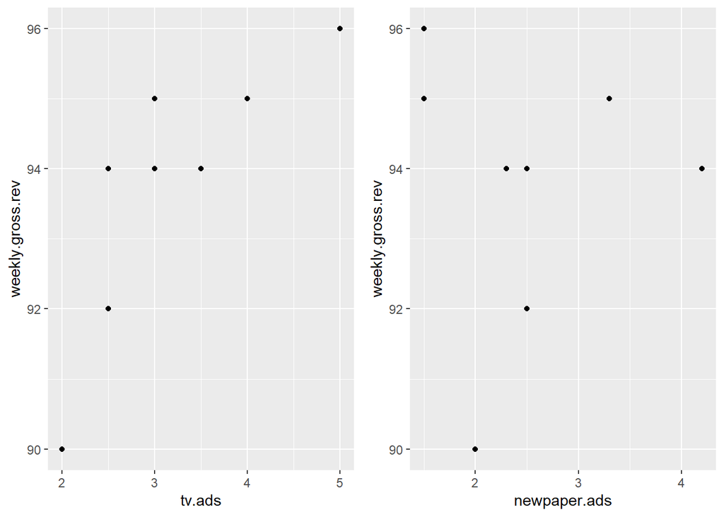

```r
g1.movie <- ggplot(movie.df, aes(x = tv.ads, y = weekly.gross.rev)) + geom_point()
g2.movie <- ggplot(movie.df, aes(x = newpaper.ads, y = weekly.gross.rev)) + geom_point()

plot_grid(g1.movie, g2.movie)
```

Q1: Develop an estimated regression equation with the amount of tv advertising as the independent variable.

```r
movie.lm <- lm(weekly.gross.rev ~ tv.ads,
               data = movie.df)

summary(movie.lm)
```

```
##
## Call:
## lm(formula = weekly.gross.rev ~ tv.ads, data = movie.df)
##
## Residuals:
##     Min      1Q  Median      3Q     Max
## -1.8454 -0.6498 -0.1522  0.7512  1.5507
##
## Coefficients:
##             Estimate Std. Error t value Pr(>|t|)
## (Intercept)  88.6377     1.5824  56.016 2.17e-09 ***
## tv.ads        1.6039     0.4778   3.357   0.0153 *
## ---
## Signif. codes:  0 '***' 0.001 '**' 0.01 '*' 0.05 '.' 0.1 ' ' 1
##
## Residual standard error: 1.215 on 6 degrees of freedom
## Multiple R-squared:  0.6526, Adjusted R-squared:  0.5946
## F-statistic: 11.27 on 1 and 6 DF,  p-value: 0.01529
```